# FinalCode

## Imports

```python
# imports
import numpy as np
from collections import defaultdict
import pandas as pd

import matplotlib.pyplot as plt
from PIL import Image, ImageDraw
```

## Creating Circles to Overlay

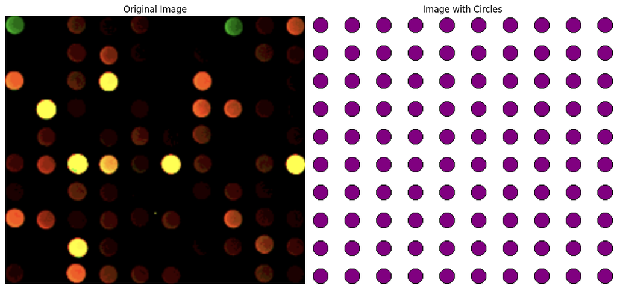

```python
# Load the image
image_path = 'PrincetonData.png'
image = Image.open(image_path)

# Convert the image to RGB and as an array
image_rgb = image.convert("RGB")
image_array = np.array(image_rgb)

# Get image dimensions
image_width, image_height = image.size

# Calculate cell size
grid_size = (10, 10)
cell_width = image_width // grid_size[0]
cell_height = image_height // grid_size[1]

# Add padding between cells
spacing_factor = 1.08  # Increase this value for more spacing
cell_width = int((image_width // grid_size[0]) * spacing_factor)
cell_height = int((image_height // grid_size[1]) * spacing_factor)

# Estimate circle diameter and scale it down (e.g., multiply by 0.5 to make it smaller)
circle_diameter = 20

# Create a blank (white) image of the same size as the original image
new_image = Image.new("RGB", (image_width, image_height), color=(255, 255, 255))  # white background

# Draw circles on the new image
draw = ImageDraw.Draw(new_image)

# Adjust offsets to position circles closer to edges without crowding
global_x_offset = cell_width // 4  # Global offset for horizontal positioning
global_y_offset = cell_height // 3  # Global offset for vertical positioning

# Calculate circle centers with adjusted offsets
for i in range(grid_size[0]):
    for j in range(grid_size[1]):
        # Calculate the adjusted center of each circle
        x_center = j * cell_width + global_x_offset
        y_center = i * cell_height + global_y_offset

        # Draw the circle (ellipse with equal width and height)
        draw.ellipse(
            [x_center - circle_diameter // 2, y_center - circle_diameter // 2,
             x_center + circle_diameter // 2, y_center + circle_diameter // 2],
            fill=(128, 0, 128),  # purple color for visibility
            outline=(0, 0, 0)  # black outline for clarity
        )


# Set up the subplot grid (1 row, 2 columns)
fig, axes = plt.subplots(1, 2, figsize=(12, 6))  # You can adjust the figure size if needed

# Show the original image on the left
axes[0].imshow(image)
axes[0].axis('off')  # Turn off axis for a cleaner view
axes[0].set_title("Original Image")

# Show the new image with circles on the right
axes[1].imshow(new_image)
axes[1].axis('off')  # Turn off axis for a cleaner view
axes[1].set_title("Image with Circles")

# Display the figure
plt.tight_layout()  # Adjust layout to prevent overlap
plt.show()
```

This code processes an image to overlay a grid of circles and displays the original image alongside the modified version for comparison. It begins by loading the image and converting it to RGB format, ensuring compatibility for manipulation. The image dimensions are used to define a 10x10 grid, with each cell's size calculated based on the image's width and height. A spacing factor is applied to ensure the circles are not too close or too far, and global offsets that adjust the circle placement within cells for more accurate alignment. A blank white canvas of the same size as the original image is created with the circles with a specified diameter, are drawn in purple with black outlines at the specific calculated grid positions. Finally, the original and modified images are displayed side by side to provide a visual idea to determine if the circles are in the right spot.

## Overlay Circles

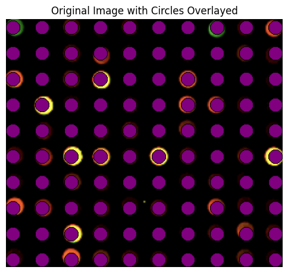

```python
# Create a copy of the original image to draw on
overlay_image = image.copy()
draw = ImageDraw.Draw(overlay_image)

# Calculate circle centers with adjusted offsets
for i in range(grid_size[0]):
    for j in range(grid_size[1]):
        # Calculate the adjusted center of each circle
        x_center = j * cell_width + global_x_offset
        y_center = i * cell_height + global_y_offset

        # Draw the circle (ellipse with equal width and height)
        draw.ellipse(
            [x_center - circle_diameter // 2, y_center - circle_diameter // 2,
             x_center + circle_diameter // 2, y_center + circle_diameter // 2],
            fill=(128, 0, 128),  # purple color for visibility
            outline=(0, 0, 0)  # black outline for clarity
        )

# Display the image with circles overlayed
plt.figure(figsize=(6, 6))
plt.imshow(overlay_image)
plt.axis('off')  # Turn off axis for a cleaner view
plt.title("Original Image with Circles Overlayed")
plt.show()
```

This code overlays the grid of circles created above directly on top of the original image and displays the result. This is done to double check that the position of the circles is accurate.

## Average Well Color

```
  Position    R    G   B
0   (0, 0)   58  131  35
1   (0, 1)    0    0   0
2   (0, 2)   64   21   5
3   (0, 3)   10    0   0
4   (0, 4)   42    5   2
5   (0, 5)    0    0   0
6   (0, 6)    0    0   0
7   (0, 7)   46  108  27
8   (0, 8)   28    1   1
9   (0, 9)  157   61  24
```

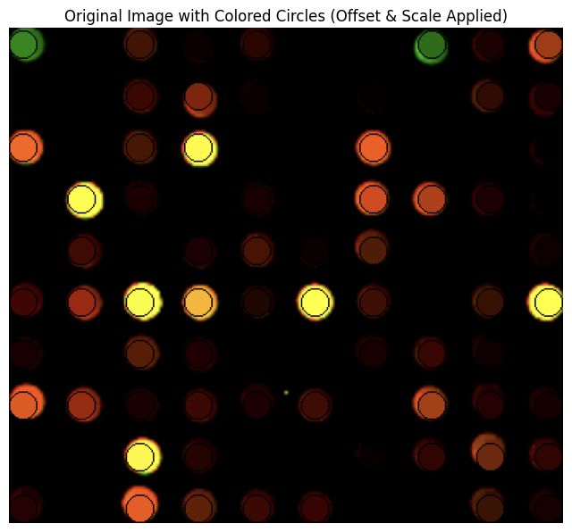

```python
# Function to calculate the average color inside a circle
def get_circle_average_color(image_array, center, diameter):
    radius = diameter // 2
    y, x = np.ogrid[:image_array.shape[0], :image_array.shape[1]]
    mask = (x - center[0])**2 + (y - center[1])**2 <= radius**2
    circle_region = image_array[mask]

    r_mean = circle_region[:, 0].mean()
    g_mean = circle_region[:, 1].mean()
    b_mean = circle_region[:, 2].mean()

    return int(r_mean), int(g_mean), int(b_mean)


# Initialize lists to store position and RGB values
positions = []
r_values = []
g_values = []
b_values = []

# Loop through the grid and extract the average color for each circle
for i in range(grid_size[0]):
    for j in range(grid_size[1]):
        # Calculate the center of each circle with offset
        x_center = j * cell_width + global_x_offset
        y_center = i * cell_height + global_y_offset

        # Get the average color inside the circle
        r_mean, g_mean, b_mean = get_circle_average_color(image_array, (x_center, y_center), circle_diameter)

        # Append the position and RGB values
        positions.append((i, j))
        r_values.append(r_mean)
        g_values.append(g_mean)
        b_values.append(b_mean)

# Create a DataFrame with the RGB values and positions
df_colors = pd.DataFrame({
    "Position": positions,
    "R": r_values,
    "G": g_values,
    "B": b_values
})

# Show the first 10 rows of the DataFrame
print(df_colors.head(10))

# Create a copy of the original image to overlay circles
overlay_image = image.copy()
draw = ImageDraw.Draw(overlay_image)

# Loop through each position and draw the circle with the corresponding color
for index, row in df_colors.iterrows():
    i, j = row['Position']
    r, g, b = row['R'], row['G'], row['B']

    # Calculate the center of each circle with offset and scale
    x_center = j * cell_width + global_x_offset
    y_center = i * cell_height + global_y_offset

    # Draw the circle on the original image copy
    draw.ellipse(
        [x_center - circle_diameter // 2, y_center - circle_diameter // 2,
         x_center + circle_diameter // 2, y_center + circle_diameter // 2],
        fill=(r, g, b),  # Fill with the extracted average color
        outline=(0, 0, 0)  # Optional: black outline for clarity
    )

# Show the overlay image with colored circles
plt.figure(figsize=(8, 8))
plt.imshow(overlay_image)
plt.axis('off')  # Turn off axis for a cleaner view
plt.title("Original Image with Colored Circles (Offset & Scale Applied)")
plt.show()

# Optionally, save the overlay image to disk
overlay_image.save('overlay_image_with_circles_offset_scaled.png')
```

This code calculates the average color inside each circle on a grid created above and displays the original image with the circles filled with the averaged colors. This is done so later we can calculate the RBG value in each well. A helper function computes the average RGB values for each circle by creating a circular mask and extracting pixel values from the original image's array. The code loops through each well in the grid, where it calculates the center for each circle, applies the mask, and appends the positions and RGB values to lists. These values are organized into a DataFrame for easy inspection and further analysis.

Then to show this as a figure a duplicate of the original image is then created, and the circles are drawn at the corresponding grid positions, filled with their calculated average color. The final overlay image is displayed with Matplotlib and saved to a file for reuse or sharing. This process highlights regional color variations in the image, making it valuable for visualization and pattern analysis in various imaging datasets.

## New Image with Averaged Colors

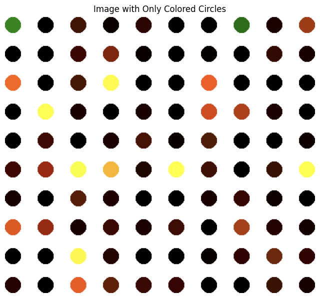

```python
# Create a new blank image for circles only
circle_image = Image.new('RGB', (image_width, image_height), (255, 255, 255))  # White background
draw = ImageDraw.Draw(circle_image)

# Loop through each position and draw the circle with the corresponding color
for index, row in df_colors.iterrows():
    i, j = row['Position']
    r, g, b = row['R'], row['G'], row['B']

    # Calculate the center of each circle with offset and scale
    x_center = j * cell_width + global_x_offset
    y_center = i * cell_height + global_y_offset

    # Draw the circle on the new image
    draw.ellipse(
        [x_center - circle_diameter // 2, y_center - circle_diameter // 2,
         x_center + circle_diameter // 2, y_center + circle_diameter // 2],
        fill=(r, g, b),  # Fill with the extracted average color
        outline=None  # No outline for a clean look
    )

# Show the image with only the colored circles
plt.figure(figsize=(8, 8))
plt.imshow(circle_image)
plt.axis('off')  # Turn off axis for a cleaner view
plt.title("Image with Only Colored Circles")
plt.show()
```

This code creates a new figure with the calcualted colors from above to reduce the background noise and allow for a clean visualization.

## Red Tiff

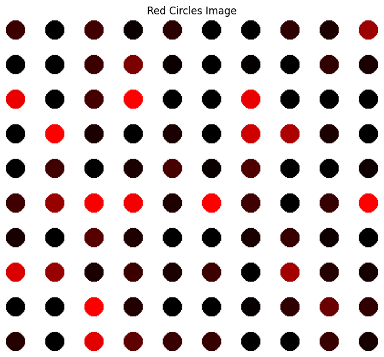

```python
# Create a new blank image for red circles only
red_circle_image = Image.new('RGB', (image_width, image_height), (255, 255, 255))  # White background
draw = ImageDraw.Draw(red_circle_image)

# Loop through each position and draw the circle with the red channel as the color
for index, row in df_colors.iterrows():
    i, j = row['Position']
    r = row['R']  # Use only the red channel
    g = b = 0     # Set green and blue to 0 for red-only colors

    # Calculate the center of each circle with offset and scale
    x_center = j * cell_width + global_x_offset
    y_center = i * cell_height + global_y_offset

    # Draw the circle on the new image
    draw.ellipse(
        [x_center - circle_diameter // 2, y_center - circle_diameter // 2,
         x_center + circle_diameter // 2, y_center + circle_diameter // 2],
        fill=(r, g, b),  # Fill with the red-only color
        outline=None     # No outline for a clean look
    )

# Save the red image as a TIFF file
red_circle_image.save('red_circles_image.tiff', format='TIFF')

# Optionally display the red TIFF image
plt.figure(figsize=(8, 8))
plt.imshow(red_circle_image)
plt.axis('off')  # Turn off axis for a cleaner view
plt.title("Red Circles Image")
plt.show()
```

This code creates a new image where only the red channel is visualized for each well. A blank image with a white background is initialized, and the script iterates over the df_colors DataFrame to extract the red intensity (R) for each grid cell. The green and blue channels are set to zero to isolate the red component. This allows us to visualize which genes are expressed by the tissue labeled with the red flourophore.

## Adding Red Intensities to a Dataframe

```python
# Load the red TIFF image
red_tiff_path = 'red_circles_image.tiff'
red_image = Image.open(red_tiff_path)
red_array = np.array(red_image)

# Initialize a list to store intensities
intensities = []

# Loop through each circle and calculate intensity
for index, row in df_colors.iterrows():
    i, j = row['Position']

    # Calculate the center of each circle
    x_center = j * cell_width + global_x_offset
    y_center = i * cell_height + global_y_offset
    radius = circle_diameter // 2

    # Create a mask for the circle region
    y, x = np.ogrid[:red_array.shape[0], :red_array.shape[1]]
    mask = (x - x_center)**2 + (y - y_center)**2 <= radius**2

    # Extract the red channel in the circle region
    circle_region_red = red_array[:, :, 0][mask]  # Only red channel

    # Calculate the intensity (e.g., sum or mean of red channel)
    intensity = circle_region_red.sum()  # Total intensity
    # intensity = circle_region_red.mean()  # Average intensity (optional)

    # Append to the list
    intensities.append(intensity)

# Add the intensities to the DataFrame
df_colors['Red Intensity'] = intensities

# Save the DataFrame to a CSV file
df_colors.to_csv('red_circles_intensities.csv', index=False)

# Display the first few rows of the DataFrame
print(df_colors.head())
```

```
  Position   R    G   B  Red Intensity
0   (0, 0)  58  131  35          18386
1   (0, 1)   0    0   0              0
2   (0, 2)  64   21   5          20288
3   (0, 3)  10    0   0           3170
4   (0, 4)  42    5   2          13314
```

This code extracts the red intensity epxressed in this photo to collect data to be used later in the code and adds it to the dataframe.

## Green Tiff

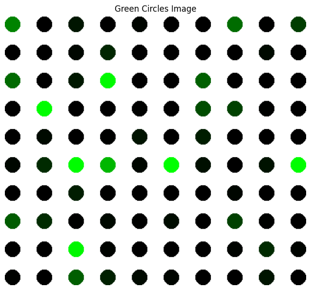

```python
# Create a new blank image for green circles only
green_circle_image = Image.new('RGB', (image_width, image_height), (255, 255, 255))  # White background
draw = ImageDraw.Draw(green_circle_image)

# Loop through each position and draw the circle with the green channel as the color
for index, row in df_colors.iterrows():
    i, j = row['Position']
    g = row['G']  # Use only the green channel
    r = b = 0     # Set red and blue to 0 for green-only colors

    # Calculate the center of each circle with offset and scale
    x_center = j * cell_width + global_x_offset
    y_center = i * cell_height + global_y_offset

    # Draw the circle on the new image
    draw.ellipse(
        [x_center - circle_diameter // 2, y_center - circle_diameter // 2,
         x_center + circle_diameter // 2, y_center + circle_diameter // 2],
        fill=(r, g, b),  # Fill with the green-only color
        outline=None     # No outline for a clean look
    )

# Save the green image as a TIFF file
green_circle_image.save('green_circles_image.tiff', format='TIFF')

# Optionally display the green TIFF image
plt.figure(figsize=(8, 8))
plt.imshow(green_circle_image)
plt.axis('off')  # Turn off axis for a cleaner view
plt.title("Green Circles Image")
plt.show()
```

This code creates a new image where only the green channel is visualized for each well. A blank image with a white background is initialized, and the script iterates over the df_colors DataFrame to extract the green intensity (G) for each grid cell. The red and blue channels are set to zero to isolate the green component. This allows us to visualize which genes are expressed by the tissue labeled with the green flourophore.

## Add Green Intensities to Dataframe

```python
# Load the green TIFF image
green_tiff_path = 'green_circles_image.tiff'
green_image = Image.open(green_tiff_path)
green_array = np.array(green_image)

# Initialize a list to store intensities
intensities = []

# Loop through each circle and calculate intensity
for index, row in df_colors.iterrows():
    i, j = row['Position']

    # Calculate the center of each circle
    x_center = j * cell_width + global_x_offset
    y_center = i * cell_height + global_y_offset
    radius = circle_diameter // 2

    # Create a mask for the circle region
    y, x = np.ogrid[:green_array.shape[0], :green_array.shape[1]]
    mask = (x - x_center)**2 + (y - y_center)**2 <= radius**2

    # Extract the green channel in the circle region
    circle_region_green = green_array[:, :, 1][mask]  # Only green channel (index 1)

    # Calculate the intensity (e.g., sum or mean of green channel)
    intensity = circle_region_green.sum()  # Total intensity
    # intensity = circle_region_green.mean()  # Average intensity (optional)

    # Append to the list
    intensities.append(intensity)

# Add the intensities to the DataFrame
df_colors['Green Intensity'] = intensities

# Save the DataFrame to a CSV file
df_colors.to_csv('green_circles_intensities.csv', index=False)

# Display the first few rows of the DataFrame
print(df_colors.head())
```

```
  Position   R    G   B  Red Intensity  Green Intensity
0   (0, 0)  58  131  35          18386            41527
1   (0, 1)   0    0   0              0                0
2   (0, 2)  64   21   5          20288             6657
3   (0, 3)  10    0   0           3170                0
4   (0, 4)  42    5   2          13314             1585
```

This code extracts the green intensity epxressed in this photo to collect data to be used later in the code and adds it to the dataframe.

## Adding Correlating Gene to Dataframe

```python
# Load the GeneCSV Excel file to get Sequence Type
gene_df = pd.read_excel('GeneCSV.xlsx')

# Add the Sequence Type column from gene_df to df_colors
# Assuming 'Gene Name' and 'Name' are in gene_df and should match the same row index as in df_colors
df_colors['Sequence Type'] = gene_df['Sequence Type']  # Add the 'Sequence Type' from gene_df to df_colors

# Initialize a new column for Gene/Control Name in df_colors
df_colors['Gene/Control Name'] = None  # Create an empty column

# Loop through each row in df_colors and add the corresponding Gene/Control Name
for index, row in df_colors.iterrows():
    sequence_type = row['Sequence Type']  # Get the Sequence Type from df_colors

    # Ensure we are only working with the correct index range in both dataframes
    if index < len(gene_df):  # Ensure index is valid for gene_df
        # Get the corresponding gene/control name from gene_df
        if sequence_type == 'OLIGO':
            # For OLIGO, use the Gene Name from gene_df
            df_colors.at[index, 'Gene/Control Name'] = gene_df.at[index, 'Gene Name']

        elif sequence_type == 'CONTROL':
            # For CONTROL, use the Name from gene_df
            df_colors.at[index, 'Gene/Control Name'] = gene_df.at[index, 'Name']

# Display the updated df_colors DataFrame
print(df_colors.head())
```

```
  Position   R    G   B  Red Intensity  Green Intensity Gene/Control Name  \
0   (0, 0)  58  131  35          18386            41527      BRIGHTCORNER
1   (0, 1)   0    0   0              0                0         (-)3XSLV1
2   (0, 2)  64   21   5          20288             6657              NHX1
3   (0, 3)  10    0   0           3170                0              SKI3
4   (0, 4)  42    5   2          13314             1585              POL5

  Sequence Type
0       CONTROL
1       CONTROL
2         OLIGO
3         OLIGO
4         OLIGO
```

This code determines which gene correlates with which well and inputs this into df_colors for further analysis, enabling the identification of sequence types and their corresponding gene or control names. It ensures consistency across the two DataFrames and prepares df_colors for downstream tasks, such as visualizations or statistical comparisons based on gene associations.

```python
df_colors
```

|  | Position | R | G | B | Red Intensity | Green Intensity | Gene/Control Name | Sequence Type |
| --- | --- | --- | --- | --- | --- | --- | --- | --- |
| 0 | (0, 0) | 58 | 131 | 35 | 18386 | 41527 | BRIGHTCORNER | CONTROL |
| 1 | (0, 1) | 0 | 0 | 0 | 0 | 0 | (-)3XSLV1 | CONTROL |
| 2 | (0, 2) | 64 | 21 | 5 | 20288 | 6657 | NHX1 | OLIGO |
| 3 | (0, 3) | 10 | 0 | 0 | 3170 | 0 | SKI3 | OLIGO |
| 4 | (0, 4) | 42 | 5 | 2 | 13314 | 1585 | POL5 | OLIGO |
| ... | ... | ... | ... | ... | ... | ... | ... | ... |
| 95 | (9, 5) | 54 | 5 | 3 | 17118 | 1585 | GIN4 | OLIGO |
| 96 | (9, 6) | 0 | 0 | 0 | 0 | 0 | NaN | OLIGO |
| 97 | (9, 7) | 0 | 0 | 0 | 0 | 0 | SLD7 | OLIGO |
| 98 | (9, 8) | 57 | 20 | 4 | 18069 | 6340 | LPL1 | OLIGO |
| 99 | (9, 9) | 23 | 0 | 0 | 7291 | 0 | NaN | OLIGO |

100 rows × 8 columns

This code visualizes the dataframe created.

## Visualizing Intensities to Determine where to Threshold

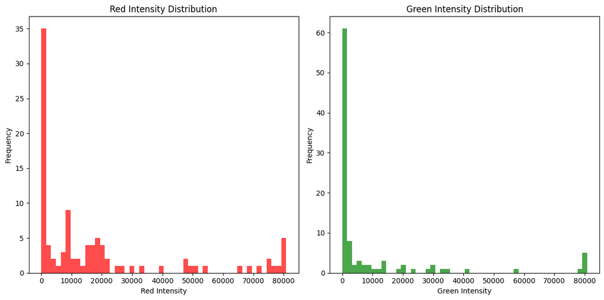

```python
import matplotlib.pyplot as plt

# Plot histograms for red and green intensities
plt.figure(figsize=(12, 6))
plt.subplot(1, 2, 1)
plt.hist(df_colors['Red Intensity'], bins=50, color='r', alpha=0.7)
plt.title('Red Intensity Distribution')
plt.xlabel('Red Intensity')
plt.ylabel('Frequency')

plt.subplot(1, 2, 2)
plt.hist(df_colors['Green Intensity'], bins=50, color='g', alpha=0.7)
plt.title('Green Intensity Distribution')
plt.xlabel('Green Intensity')
plt.ylabel('Frequency')

plt.tight_layout()
plt.show()
```

This code creates a histagram so we are able to determine where we should threshold when creating our heatmap so we can leave out the wells with no binding of cDNA to the oligonucleotide.

```python
# Define the threshold values for red and green intensities
red_threshold = 5000  # Adjust this based on your desired threshold
green_threshold = 5000  # Adjust this based on your desired threshold

# Create a new DataFrame for wells with decent color
colored_wells_df = df_colors[(df_colors['Red Intensity'] >= red_threshold) |
                             (df_colors['Green Intensity'] >= green_threshold)]

# Display the new DataFrame with decent color wells
print(colored_wells_df)
```

```
   Position    R    G   B  Red Intensity  Green Intensity Gene/Control Name  \
0    (0, 0)   58  131  35          18386            41527      BRIGHTCORNER
2    (0, 2)   64   21   5          20288             6657              NHX1
4    (0, 4)   42    5   2          13314             1585              POL5
7    (0, 7)   46  108  27          14582            34236      (+)PRO25G-02
8    (0, 8)   28    1   1           8876              317              ALG5
9    (0, 9)  157   61  24          49769            19337             SEC61
12   (1, 2)   58    7   3          18386             2219             RPC34
13   (1, 3)  124   38  16          39308            12046              HHO1
18   (1, 8)   49   10   3          15533             3170              TED1
19   (1, 9)   26    1   1           8242              317              PFD1
20   (2, 0)  235  106  44          74495            33602               NaN
22   (2, 2)   68   24   5          21556             7608               NaN
23   (2, 3)  254  250  83          80518            79250            RPS22A
26   (2, 6)  235   96  42          74495            30432               NaN
```

[output cut: 106 more lines]

This code creates a new dataframe after thresholding the df_colors dataframe to include only wells that express some flourescence.

## Heatmap

[figure not shown]

```python
# Normalize both red and green intensities to the range [0, 1]
colored_wells_df['Red Intensity Normalized'] = colored_wells_df['Red Intensity'] / colored_wells_df['Red Intensity'].max()
colored_wells_df['Green Intensity Normalized'] = colored_wells_df['Green Intensity'] / colored_wells_df['Green Intensity'].max()

# Calculate the normalized combined intensity
colored_wells_df['Normalized Combined Intensity'] = (colored_wells_df['Red Intensity Normalized'] +
                                                      colored_wells_df['Green Intensity Normalized'])

# Create a heatmap with the combined normalized intensity values
plt.figure(figsize=(10, 8))
sns.heatmap(colored_wells_df[['Normalized Combined Intensity']], annot=True, cmap='YlGnBu', cbar=True, fmt='.2f',
            xticklabels=['Normalized Combined Intensity'], yticklabels=True)

# Set title and labels
plt.title('Heatmap of Normalized Combined Intensity (Red + Green) for Each Gene')
plt.xlabel('Normalized Combined Intensity')
plt.ylabel('Gene Name')

# Display the heatmap
plt.show()
```

low means they both show low intensities for each well